# HW2 - 250620601

Ravin Lathigra

October 14, 2018

```r
set.seed(100)
sub_index = sample(nrow(mtcars),20,replace=FALSE)
mtcars2 = mtcars[sub_index, c(1,2,4)]

knitr::kable(summary(mtcars2), caption = "Summary of mtcars2 Data") %>%
  kable_styling() %>%
  scroll_box(width = "100%", height = "600px")
```

Summary of mtcars2 Data

[output not shown]

[output not shown]

[output not shown]

Min. :10.4

Min. :4

Min. : 52.0

1st Qu.:15.2

1st Qu.:4

1st Qu.: 94.0

Median :20.1

Median :6

Median :111.5

Mean :20.6

Mean :6

Mean :138.8

3rd Qu.:24.8

3rd Qu.:8

3rd Qu.:180.0

Max. :33.9

Max. :8

Max. :335.0

```r
str(mtcars2)
```

```
## 'data.frame':    20 obs. of  3 variables:
##  $ mpg: num  19.2 24.4 14.7 21 15.2 30.4 15.5 21.4 26 21.4 ...
##  $ cyl: num  6 4 8 6 8 4 8 4 4 6 ...
##  $ hp : num  123 62 230 110 180 113 150 109 91 110 ...
```

```r
mtcars2 <- mtcars2 %>%
  mutate(cyl = as.numeric(cyl))
```

## Question 1a

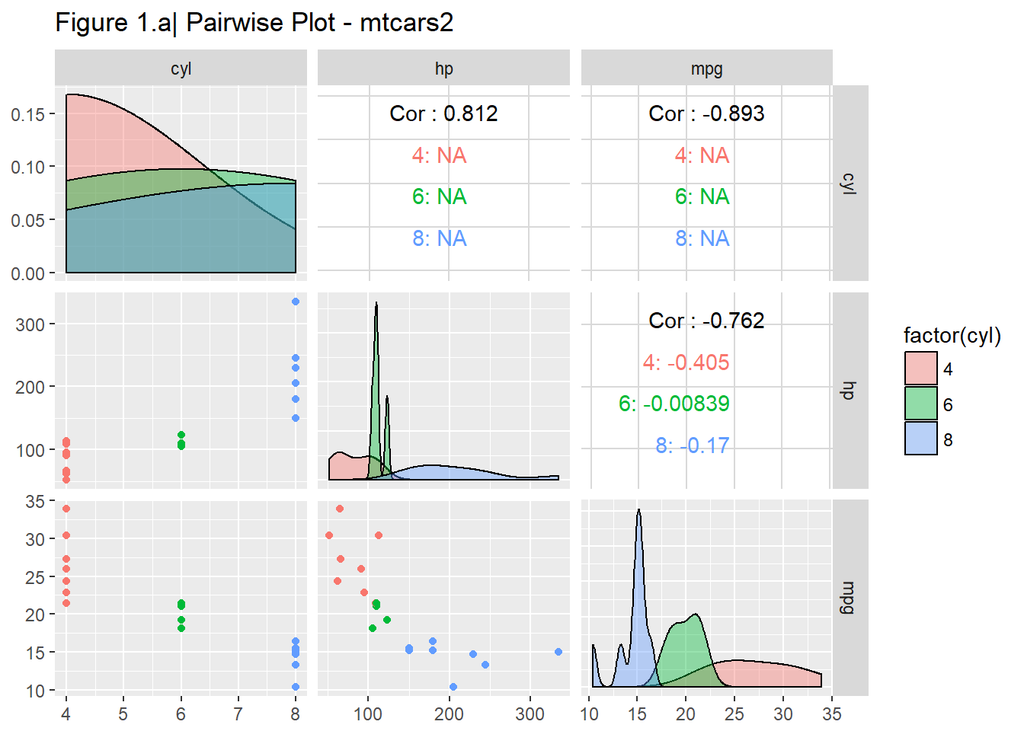

```r
ggpairs(mtcars2[,c(2,3,1)],
        aes(colour = factor(cyl)),
        diag = list(continuous = wrap("densityDiag", alpha = 0.4)),
        lower = list(continous = wrap("points", alpha = 0.4), combo = "dot"),
        upper = list(continuous = "cor", combo = "box_no_facet"),
        title = "Figure 1.a| Pairwise Plot - mtcars2",
        legend = 1
       )
```

Figure 1.a above shows a ggpairs plot in which 3 comparisons can be visualized from the data.

- Upper: Pairwise correlation in aggregate (all classes) and by cyl.
- Diagonal: Smoothed density estimate using Gaussian kernal estimate. While density comparisons may be appropriate for continuous data, for cyl, it may not be the most appropriate method to visualize distribution.
- Lower: Pairwise scatterplots among parameters, split by cyl.

**Hp Vs. Cyl**

From figure 1.a, it can be seen that there is a positive generally linear relationship between hp and cyl. It is worth noting that there apprears to be an outlier in the 8 cyl class. This data point is from the maserati bora whose hp greatly exceeds the avg horsepower amongst cars with 8 cyl. Correlation cannot be calculated within class as there is no standard deviation of cyl, but in aggregate there is a correlation of 0.812 which supports the claim that there is a positive relationship between hp and cyl.

**Mpg Vs. Cyl**

From figure 1.a, it can be seen that there is a negative generally linear relationship between mpg and cyl. The most extreme outlier is for the toyota corolla whose mpg exceeds that of the average car with 4 cyl. Correlation cannot be calculated within class as there is no standard deviation of cyl, but in aggregate there is a correlation of -0.893 which supports the claim that there is a negative relationship between mpg and cyl.

**Mpg Vs. Hp**

From figure 1.a, it can be seen that there is a inverse relationship between between mpg and cyl. Unlike the previous relationships, there seems to be a more curved relationship perhaps indicating a decreasing worsening in mpg as hp increases. If the outlier is removed i.e maserati bora the relationship seems more linear. This inverse relationship between mpg and hp is supported by a correlation of -0.762.

## Question 1b

```r
mpg_lm <- lm(mpg~., data = mtcars2)


summary(mpg_lm)
```

```
##
## Call:
## lm(formula = mpg ~ ., data = mtcars2)
##
## Residuals:
##     Min      1Q  Median      3Q     Max
## -5.1775 -1.8221  0.3529  0.9954  6.8980
##
## Coefficients:
##              Estimate Std. Error t value Pr(>|t|)
## (Intercept) 39.009142   2.541303  15.350 2.15e-11 ***
## cyl         -2.845021   0.652236  -4.362 0.000424 ***
## hp          -0.009647   0.016575  -0.582 0.568181
## ---
## Signif. codes:  0 '***' 0.001 '**' 0.01 '*' 0.05 '.' 0.1 ' ' 1
##
## Residual standard error: 3.048 on 17 degrees of freedom
## Multiple R-squared:  0.8019, Adjusted R-squared:  0.7786
## F-statistic: 34.41 on 2 and 17 DF,  p-value: 1.056e-06
```

Fitting a linear model to the mtcars data such that:

$$Y_{i} = \beta_{0} +\beta_{cyl}x_{i1}+\beta_{hp}x_{i2}+\epsilon_{i}$$

The percent of variation in fuel consumption that is explained by the model is 80.19%.

The estimated coefficients are:

$$\beta_{0} = 39.009142$$
$$\beta_{cyl} = -2.845021$$
$$\beta_{hp} = -0.009647$$

The coefficients suggest that hp and cyl are inversly related to mpg which we estimated in part a, and that hp doesn’t contribute or contributes only a small amount to the predicted mpg.

## Question 1c

```r
ci_cyl <- confint(mpg_lm,level = 0.90)

ci_cyl
```

```
##                     5 %       95 %
## (Intercept) 34.58827424 43.4300102
## cyl         -3.97965418 -1.7103876
## hp          -0.03848059  0.0191864
```

A 90% confidence interval for:
$$\beta_{cyl}$$
is calculated by
$$\hat{\beta_{cyl}} \pm tstat * SE$$
CI: [-3.97,-1.71]

## Question 1d

```r
new_data <- data.frame(id = c("A","B","C"),
                       cyl = c(4,6,8),
                       hp = c(90,150,210))


predict_mpg <-  predict(mpg_lm,newdata = new_data, interval = "prediction", level = 0.90)

predict_mpg
```

```
##        fit       lwr      upr
## 1 26.76082 21.150685 32.37096
## 2 20.49195 15.048479 25.93543
## 3 14.22309  8.625828 19.82034
```

## Question 1e

Given what we have already observed, the 90% prediction interval for Car C is [8.626,19.820], therefore it is very unlikely that the actual fuel efficieny for this car is 3 mpg.

## Question 1f

```r
mpg_null <- lm(mpg~1,data=mtcars2)

mpg_anova <- anova(mpg_null, mpg_lm)



Anova_tbl <- data.frame(Source = c("Regression","Error","Total"),
          `Sum of Squares` = c(mpg_anova$`Sum of Sq`[2],
                               mpg_anova$RSS[2],
                               mpg_anova$RSS[1]),
          Df = c(mpg_anova$Df[2],
                 mpg_anova$Res.Df[2],
                 mpg_anova$Res.Df[1]),
          `Mean Squares` = c(mpg_anova$`Sum of Sq`[2]/mpg_anova$Df[2],
                             mpg_anova$RSS[2]/mpg_anova$Res.Df[2],
                             "N/A"),
          `F` = c((mpg_anova$`Sum of Sq`[2]/mpg_anova$Df[2])/(mpg_anova$RSS[2]/mpg_anova$Res.Df[2]),"N/A","N/A")
)

Anova_tbl
```

```
##       Source Sum.of.Squares Df     Mean.Squares                F
## 1 Regression       639.4486  2 319.724296314555 34.4069419131415
## 2      Error       157.9714 17 9.29243572769943              N/A
## 3      Total       797.4200 19              N/A              N/A
```

## Question 1g

```r
mpg_anova
```

```
## Analysis of Variance Table
##
## Model 1: mpg ~ 1
## Model 2: mpg ~ cyl + hp
##   Res.Df    RSS Df Sum of Sq      F    Pr(>F)
## 1     19 797.42
## 2     17 157.97  2    639.45 34.407 1.056e-06 ***
## ---
## Signif. codes:  0 '***' 0.001 '**' 0.01 '*' 0.05 '.' 0.1 ' ' 1
```

Considering the following null hypthesis:
$$H_{o}: \beta_{cyl},\beta_{hp} = 0$$
and althernative hypthesis:
$$H_{a}: \exists \ \ \beta_{cyl},\beta_{hp} \ne 0$$
and
$$\alpha = 0.05$$

Anova analysis shows that there are at least one predictor has a strong linear relationship with the response variable ,mpg, therfore we should reject the null hypothesis. This is indicated by a p-value that is less that the significance level (0.05).

## Question 1h

```r
mpg_red  <- lm(mpg~cyl, data= mtcars2)

anova(mpg_red,mpg_lm)
```

```
## Analysis of Variance Table
##
## Model 1: mpg ~ cyl
## Model 2: mpg ~ cyl + hp
##   Res.Df    RSS Df Sum of Sq      F Pr(>F)
## 1     18 161.12
## 2     17 157.97  1     3.148 0.3388 0.5682
```

Considering the following null hypthesis:
$$H_{o}:\beta_{hp} = 0$$
and althernative hypthesis:
$$H_{a}: \beta_{hp} \ne 0$$
and
$$\alpha = 0.05$$

Anova analysis shows that hp does not have strong linear relationship with the response variable ,mpg, therfore we fail to reject the null hypothesis. This is indicated by a p-value that is greater that the significance level (0.05).

## Question 1i

```r
mpg_red_lm <- lm(mpg~ hp, data= mtcars2)
anova(mpg_null,mpg_red_lm)
```

```
## Analysis of Variance Table
##
## Model 1: mpg ~ 1
## Model 2: mpg ~ hp
##   Res.Df    RSS Df Sum of Sq      F    Pr(>F)
## 1     19 797.42
## 2     18 334.78  1    462.64 24.875 9.539e-05 ***
## ---
## Signif. codes:  0 '***' 0.001 '**' 0.01 '*' 0.05 '.' 0.1 ' ' 1
```

Considering the following, where hp is the only predictor considered, null hypthesis:
$$H_{o}: \beta_{hp} = 0$$
and althernative hypthesis:
$$H_{a}:\beta_{hp} \ne 0$$
and
$$\alpha = 0.05$$

## Question 1j

Part i contradicted what we found in part h, which is caused by the information that is no longer being provided by the cyl predictor. In the presence of cyl, hp offers no predictive power however without that information, hp is required to make predictions.

## Question 1k

```r
set.seed(2)
sub_index = sample(nrow(mtcars),27,replace=FALSE)
mtcars3 = mtcars[sub_index, c(1:4,10)]

knitr::kable(summary(mtcars3), caption = "Summary of mtcars3 Data") %>%
  kable_styling() %>%
  scroll_box(width = "100%", height = "600px")
```

Summary of mtcars3 Data

[output not shown]

[output not shown]

[output not shown]

[output not shown]

[output not shown]

Min. :10.40

Min. :4

Min. : 71.1

Min. : 52.0

Min. :3.000

1st Qu.:15.65

1st Qu.:4

1st Qu.:120.2

1st Qu.: 94.0

1st Qu.:3.000

Median :21.00

Median :6

Median :160.0

Median :110.0

Median :4.000

Mean :20.67

Mean :6

Mean :223.0

Mean :142.5

Mean :3.741

3rd Qu.:23.60

3rd Qu.:8

3rd Qu.:311.0

3rd Qu.:180.0

3rd Qu.:4.000

Max. :33.90

Max. :8

Max. :472.0

Max. :335.0

Max. :5.000

```r
str(mtcars3)
```

```
## 'data.frame':    27 obs. of  5 variables:
##  $ mpg : num  18.1 15.5 32.4 18.7 26 27.3 21.4 21.5 16.4 17.3 ...
##  $ cyl : num  6 8 4 8 4 4 6 4 8 8 ...
##  $ disp: num  225 318 78.7 360 120.3 ...
##  $ hp  : num  105 150 66 175 91 66 110 97 180 180 ...
##  $ gear: num  3 3 4 3 5 4 3 3 3 3 ...
```

```r
mpg_lm_lrg <- lm(mpg~ cyl+disp+hp+gear, data= mtcars3)


summary(mpg_lm_lrg)
```

```
##
## Call:
## lm(formula = mpg ~ cyl + disp + hp + gear, data = mtcars3)
##
## Residuals:
##     Min      1Q  Median      3Q     Max
## -3.6045 -2.2686 -0.9841  1.4970  6.5415
##
## Coefficients:
##             Estimate Std. Error t value Pr(>|t|)
## (Intercept) 26.64372    6.49374   4.103 0.000469 ***
## cyl         -0.40169    0.89094  -0.451 0.656502
## disp        -0.02126    0.01275  -1.667 0.109608
## hp          -0.02938    0.02133  -1.378 0.182170
## gear         1.43585    1.27749   1.124 0.273144
## ---
## Signif. codes:  0 '***' 0.001 '**' 0.01 '*' 0.05 '.' 0.1 ' ' 1
##
## Residual standard error: 2.953 on 22 degrees of freedom
## Multiple R-squared:  0.8156, Adjusted R-squared:  0.7821
## F-statistic: 24.32 on 4 and 22 DF,  p-value: 8.364e-08
```

Having large p-values (larger than significance level) does not imply that none of the predictors is lineraly related with the response variable. It could be caused by highly correlated predictors which can be resolved by correcting for multicollinearity. Depending on the data, it could also indicate that a linear model is not appropriate, though testing for multicolinearity should be considered first.

## Question 1l

```r
mpg_null_2 <- lm(mpg~ cyl, data= mtcars3)

anova(mpg_null_2,mpg_lm_lrg)
```

```
## Analysis of Variance Table
##
## Model 1: mpg ~ cyl
## Model 2: mpg ~ cyl + disp + hp + gear
##   Res.Df    RSS Df Sum of Sq      F  Pr(>F)
## 1     25 276.53
## 2     22 191.78  3    84.745 3.2404 0.04159 *
## ---
## Signif. codes:  0 '***' 0.001 '**' 0.01 '*' 0.05 '.' 0.1 ' ' 1
```

```r
summary(mpg_lm_lrg)
```

```
##
## Call:
## lm(formula = mpg ~ cyl + disp + hp + gear, data = mtcars3)
##
## Residuals:
##     Min      1Q  Median      3Q     Max
## -3.6045 -2.2686 -0.9841  1.4970  6.5415
##
## Coefficients:
##             Estimate Std. Error t value Pr(>|t|)
## (Intercept) 26.64372    6.49374   4.103 0.000469 ***
## cyl         -0.40169    0.89094  -0.451 0.656502
## disp        -0.02126    0.01275  -1.667 0.109608
## hp          -0.02938    0.02133  -1.378 0.182170
## gear         1.43585    1.27749   1.124 0.273144
## ---
## Signif. codes:  0 '***' 0.001 '**' 0.01 '*' 0.05 '.' 0.1 ' ' 1
##
## Residual standard error: 2.953 on 22 degrees of freedom
## Multiple R-squared:  0.8156, Adjusted R-squared:  0.7821
## F-statistic: 24.32 on 4 and 22 DF,  p-value: 8.364e-08
```

The p-value of 0.04159 is less than the significance level therefore we reject the null that disp, hp and gear are not lineraly related to the response.

## Question 1m

```r
mpg_null_3 <- lm(mpg~ hp +gear, data= mtcars3)

anova(mpg_null_3,mpg_lm_lrg)
```

```
## Analysis of Variance Table
##
## Model 1: mpg ~ hp + gear
## Model 2: mpg ~ cyl + disp + hp + gear
##   Res.Df    RSS Df Sum of Sq      F Pr(>F)
## 1     24 229.21
## 2     22 191.78  2    37.426 2.1466 0.1407
```

```r
summary(mpg_lm_lrg)
```

```
##
## Call:
## lm(formula = mpg ~ cyl + disp + hp + gear, data = mtcars3)
##
## Residuals:
##     Min      1Q  Median      3Q     Max
## -3.6045 -2.2686 -0.9841  1.4970  6.5415
##
## Coefficients:
##             Estimate Std. Error t value Pr(>|t|)
## (Intercept) 26.64372    6.49374   4.103 0.000469 ***
## cyl         -0.40169    0.89094  -0.451 0.656502
## disp        -0.02126    0.01275  -1.667 0.109608
## hp          -0.02938    0.02133  -1.378 0.182170
## gear         1.43585    1.27749   1.124 0.273144
## ---
## Signif. codes:  0 '***' 0.001 '**' 0.01 '*' 0.05 '.' 0.1 ' ' 1
##
## Residual standard error: 2.953 on 22 degrees of freedom
## Multiple R-squared:  0.8156, Adjusted R-squared:  0.7821
## F-statistic: 24.32 on 4 and 22 DF,  p-value: 8.364e-08
```

In this case our p value exceeds our significance level and we fail to reject our null that disp and cyl together did not improve our prediction.